# Data Visualization on Youtube Trending Videos

Faisal Amir Maz

May 10, 2023

# The Workflow

1. Start with Business Question
2. Preparing the data
3. Visualizing the data

## Study Case: “US Trending Videos”

We want to analyze what kind of video that goes viral. This will help us to decide what kind of videos that people love to watch.

## Read Data

```r
# read
vids <- read.csv("data_input/USvideos.csv")
```

```r
# inspect
head(vids)
```

|  | trending_date | title | channel_title | category_id | publish_time | views | likes | dislikes | comment_count | comments_disabled | ratings_disabled | video_error_or_removed |
| --- | --- | --- | --- | --- | --- | --- | --- | --- | --- | --- | --- | --- |
| 1 | 17.14.11 | WE WANT TO TALK ABOUT OUR MARRIAGE | CaseyNeistat | 22 | 2017-11-13T17:13:01.000Z | 748374 | 57527 | 2966 | 15954 | FALSE | FALSE | FALSE |
| 2 | 17.14.11 | The Trump Presidency: Last Week Tonight with John Oliver (HBO) | LastWeekTonight | 24 | 2017-11-13T07:30:00.000Z | 2418783 | 97185 | 6146 | 12703 | FALSE | FALSE | FALSE |
| 3 | 17.14.11 | Racist Superman \| Rudy Mancuso, King Bach & Lele Pons | Rudy Mancuso | 23 | 2017-11-12T19:05:24.000Z | 3191434 | 146033 | 5339 | 8181 | FALSE | FALSE | FALSE |
| 4 | 17.14.11 | Nickelback Lyrics: Real or Fake? | Good Mythical Morning | 24 | 2017-11-13T11:00:04.000Z | 343168 | 10172 | 666 | 2146 | FALSE | FALSE | FALSE |
| 5 | 17.14.11 | I Dare You: GOING BALD!? | nigahiga | 24 | 2017-11-12T18:01:41.000Z | 2095731 | 132235 | 1989 | 17518 | FALSE | FALSE | FALSE |
| 6 | 17.14.11 | 2 Weeks with iPhone X | iJustine | 28 | 2017-11-13T19:07:23.000Z | 119180 | 9763 | 511 | 1434 | FALSE | FALSE | FALSE |

YouTube’s US Trending Videos is a compilation of 200 videos per day from 2017-11-14 until 2018-01-21. Below is the column descriptions:

- **trending_date**: trending date
- **title**: video title
- **channel_title**: channel name
- **category_id**: video category
- **publish_time**: publish time
- **views**: views count
- **likes**: likes count
- **dislikes**: dislikes count
- **comment_count**: comment count
- **comment_disabled**: status whether comment disabled or not
- **rating_disabled**: status wheter video rating disabled or not
- **video_error_or_removed**: status whether video is deleted or not

Unused column:

1. comments_disabled
2. ratings_disabled
3. video_error_or_removed

Columnt with incorect data type:

1. trending date -> date
2. publish time -> date-time (POXIXct)
3. category id -> factor (dan diubah ke label kategori aslinya)

## Data Wrangling

1. Delete unused columns

```r
vids <- vids[,-c(10:12)]

head(vids)
```

|  | trending_date | title | channel_title | category_id | publish_time | views | likes | dislikes | comment_count |
| --- | --- | --- | --- | --- | --- | --- | --- | --- | --- |
| 1 | 17.14.11 | WE WANT TO TALK ABOUT OUR MARRIAGE | CaseyNeistat | 22 | 2017-11-13T17:13:01.000Z | 748374 | 57527 | 2966 | 15954 |
| 2 | 17.14.11 | The Trump Presidency: Last Week Tonight with John Oliver (HBO) | LastWeekTonight | 24 | 2017-11-13T07:30:00.000Z | 2418783 | 97185 | 6146 | 12703 |
| 3 | 17.14.11 | Racist Superman \| Rudy Mancuso, King Bach & Lele Pons | Rudy Mancuso | 23 | 2017-11-12T19:05:24.000Z | 3191434 | 146033 | 5339 | 8181 |
| 4 | 17.14.11 | Nickelback Lyrics: Real or Fake? | Good Mythical Morning | 24 | 2017-11-13T11:00:04.000Z | 343168 | 10172 | 666 | 2146 |
| 5 | 17.14.11 | I Dare You: GOING BALD!? | nigahiga | 24 | 2017-11-12T18:01:41.000Z | 2095731 | 132235 | 1989 | 17518 |
| 6 | 17.14.11 | 2 Weeks with iPhone X | iJustine | 28 | 2017-11-13T19:07:23.000Z | 119180 | 9763 | 511 | 1434 |

2. Change data type on `category_id`

We’ll use `switch()` & `sapply()`:

```r
# ubah isi kolom
vids$category_id <- sapply(as.character(vids$category_id), switch,
                           "1" = "Film and Animation",
                           "2" = "Autos and Vehicles",
                           "10" = "Music",
                           "15" = "Pets and Animals",
                           "17" = "Sports",
                           "19" = "Travel and Events",
                           "20" = "Gaming",
                           "22" = "People and Blogs",
                           "23" = "Comedy",
                           "24" = "Entertainment",
                           "25" = "News and Politics",
                           "26" = "Howto and Style",
                           "27" = "Education",
                           "28" = "Science and Technology",
                           "29" = "Nonprofit and Activism",
                           "43" = "Shows")

# ubah ke tipe factor
vids$category_id <- as.factor(vids$category_id)
```

```r
# cek data
head(vids)
```

|  | trending_date | title | channel_title | category_id | publish_time | views | likes | dislikes | comment_count |
| --- | --- | --- | --- | --- | --- | --- | --- | --- | --- |
| 1 | 17.14.11 | WE WANT TO TALK ABOUT OUR MARRIAGE | CaseyNeistat | People and Blogs | 2017-11-13T17:13:01.000Z | 748374 | 57527 | 2966 | 15954 |
| 2 | 17.14.11 | The Trump Presidency: Last Week Tonight with John Oliver (HBO) | LastWeekTonight | Entertainment | 2017-11-13T07:30:00.000Z | 2418783 | 97185 | 6146 | 12703 |
| 3 | 17.14.11 | Racist Superman \| Rudy Mancuso, King Bach & Lele Pons | Rudy Mancuso | Comedy | 2017-11-12T19:05:24.000Z | 3191434 | 146033 | 5339 | 8181 |
| 4 | 17.14.11 | Nickelback Lyrics: Real or Fake? | Good Mythical Morning | Entertainment | 2017-11-13T11:00:04.000Z | 343168 | 10172 | 666 | 2146 |
| 5 | 17.14.11 | I Dare You: GOING BALD!? | nigahiga | Entertainment | 2017-11-12T18:01:41.000Z | 2095731 | 132235 | 1989 | 17518 |
| 6 | 17.14.11 | 2 Weeks with iPhone X | iJustine | Science and Technology | 2017-11-13T19:07:23.000Z | 119180 | 9763 | 511 | 1434 |

1. Turn `trending_date` column into *date* using lubridate package.
2. Turn `publish_time` column into *date-time* with *timezone “America/New_York”* (`tz = "America/New_York"`)!

```r
library(lubridate)

vids$trending_date <- ydm(vids$trending_date)

vids$publish_time <- ymd_hms(vids$publish_time, tz = "America/New_York")

head(vids)
```

|  | trending_date | title | channel_title | category_id | publish_time | views | likes | dislikes | comment_count |
| --- | --- | --- | --- | --- | --- | --- | --- | --- | --- |
| 1 | 2017-11-14 | WE WANT TO TALK ABOUT OUR MARRIAGE | CaseyNeistat | People and Blogs | 2017-11-13 12:13:01 | 748374 | 57527 | 2966 | 15954 |
| 2 | 2017-11-14 | The Trump Presidency: Last Week Tonight with John Oliver (HBO) | LastWeekTonight | Entertainment | 2017-11-13 02:30:00 | 2418783 | 97185 | 6146 | 12703 |
| 3 | 2017-11-14 | Racist Superman \| Rudy Mancuso, King Bach & Lele Pons | Rudy Mancuso | Comedy | 2017-11-12 14:05:24 | 3191434 | 146033 | 5339 | 8181 |
| 4 | 2017-11-14 | Nickelback Lyrics: Real or Fake? | Good Mythical Morning | Entertainment | 2017-11-13 06:00:04 | 343168 | 10172 | 666 | 2146 |
| 5 | 2017-11-14 | I Dare You: GOING BALD!? | nigahiga | Entertainment | 2017-11-12 13:01:41 | 2095731 | 132235 | 1989 | 17518 |
| 6 | 2017-11-14 | 2 Weeks with iPhone X | iJustine | Science and Technology | 2017-11-13 14:07:23 | 119180 | 9763 | 511 | 1434 |

[Cheatsheet Lubridate](https://raw.githubusercontent.com/rstudio/cheatsheets/main/lubridate.pdf)

### Feature Engineering

In this part we’re going to make a new column or information using the data. This is useful for data exploration, and modelling.

1. Extract “publish_time” hour into s new column `publish_hour`

```r
vids$publish_hour <- hour(vids$publish_time)
```

2. Make a column named `publish_when` from publish hour into some range of time using `if else()`:

we’re going to make 3 perion of time: 1. 12am to 8am 2. 8am to 4pm 3. 4pm to 12am

```r
pw <- function(x){

  if(x < 8){x <- "12am to 8am"}
  else if(x >= 8 & x < 16){x <- "8am to 4pm"}
  else{x <- "4pm to 12am"}

}
```

```r
# use `sapply()` to apply the function into whole rows
vids$publish_when <- sapply(vids$publish_hour, pw)

# change to factor
vids$publish_when <- as.factor(vids$publish_when)
```

3. Extract day data into `publish_wday` column.

```r
vids$publish_wday <- wday(vids$publish_time,
                          label = T, # menampilkan nama hari nya
                          week_start = 1 # bisa atur urutan hari untuk awal minggu
                          # locale = "Indonesian"
                          )

head(vids)
```

|  | trending_date | title | channel_title | category_id | publish_time | views | likes | dislikes | comment_count | publish_hour | publish_when | publish_wday |
| --- | --- | --- | --- | --- | --- | --- | --- | --- | --- | --- | --- | --- |
| 1 | 2017-11-14 | WE WANT TO TALK ABOUT OUR MARRIAGE | CaseyNeistat | People and Blogs | 2017-11-13 12:13:01 | 748374 | 57527 | 2966 | 15954 | 12 | 8am to 4pm | Mon |
| 2 | 2017-11-14 | The Trump Presidency: Last Week Tonight with John Oliver (HBO) | LastWeekTonight | Entertainment | 2017-11-13 02:30:00 | 2418783 | 97185 | 6146 | 12703 | 2 | 12am to 8am | Mon |
| 3 | 2017-11-14 | Racist Superman \| Rudy Mancuso, King Bach & Lele Pons | Rudy Mancuso | Comedy | 2017-11-12 14:05:24 | 3191434 | 146033 | 5339 | 8181 | 14 | 8am to 4pm | Sun |
| 4 | 2017-11-14 | Nickelback Lyrics: Real or Fake? | Good Mythical Morning | Entertainment | 2017-11-13 06:00:04 | 343168 | 10172 | 666 | 2146 | 6 | 12am to 8am | Mon |
| 5 | 2017-11-14 | I Dare You: GOING BALD!? | nigahiga | Entertainment | 2017-11-12 13:01:41 | 2095731 | 132235 | 1989 | 17518 | 13 | 8am to 4pm | Sun |
| 6 | 2017-11-14 | 2 Weeks with iPhone X | iJustine | Science and Technology | 2017-11-13 14:07:23 | 119180 | 9763 | 511 | 1434 | 14 | 8am to 4pm | Mon |

Table of locales: https://docs.moodle.org/dev/Table_of_locales

4. calculate the likes per view, dislikes per view, and comment per view into more proportional statistic view.

```r
vids$likesp <- vids$likes/vids$views
vids$dislikesp <- vids$dislikes/vids$views
vids$commentp <- vids$comment_count/vids$views

head(vids)
```

|  | trending_date | title | channel_title | category_id | publish_time | views | likes | dislikes | comment_count | publish_hour | publish_when | publish_wday | likesp | dislikesp | commentp |
| --- | --- | --- | --- | --- | --- | --- | --- | --- | --- | --- | --- | --- | --- | --- | --- |
| 1 | 2017-11-14 | WE WANT TO TALK ABOUT OUR MARRIAGE | CaseyNeistat | People and Blogs | 2017-11-13 12:13:01 | 748374 | 57527 | 2966 | 15954 | 12 | 8am to 4pm | Mon | 0.07686932 | 0.0039632590 | 0.021318218 |
| 2 | 2017-11-14 | The Trump Presidency: Last Week Tonight with John Oliver (HBO) | LastWeekTonight | Entertainment | 2017-11-13 02:30:00 | 2418783 | 97185 | 6146 | 12703 | 2 | 12am to 8am | Mon | 0.04017930 | 0.0025409472 | 0.005251815 |
| 3 | 2017-11-14 | Racist Superman \| Rudy Mancuso, King Bach & Lele Pons | Rudy Mancuso | Comedy | 2017-11-12 14:05:24 | 3191434 | 146033 | 5339 | 8181 | 14 | 8am to 4pm | Sun | 0.04575780 | 0.0016729157 | 0.002563424 |
| 4 | 2017-11-14 | Nickelback Lyrics: Real or Fake? | Good Mythical Morning | Entertainment | 2017-11-13 06:00:04 | 343168 | 10172 | 666 | 2146 | 6 | 12am to 8am | Mon | 0.02964146 | 0.0019407404 | 0.006253497 |
| 5 | 2017-11-14 | I Dare You: GOING BALD!? | nigahiga | Entertainment | 2017-11-12 13:01:41 | 2095731 | 132235 | 1989 | 17518 | 13 | 8am to 4pm | Sun | 0.06309732 | 0.0009490722 | 0.008358897 |
| 6 | 2017-11-14 | 2 Weeks with iPhone X | iJustine | Science and Technology | 2017-11-13 14:07:23 | 119180 | 9763 | 511 | 1434 | 14 | 8am to 4pm | Mon | 0.08191811 | 0.0042876322 | 0.012032220 |

### Filter Unique Videos

There are redundant in vids data because some trending videos appear mutiple times due to trending in more than a day.

```r
length(vids$title)
```

```
#> [1] 13400
```

```r
length(unique(vids$title))
```

```
#> [1] 2986
```

We’ll use `unique()` dan `match()` to solve this.

- **unique**: select unique value of a vector
- **match**: select the the first index that *match* between 2 vectors

By combining this two techniques we can select the data when the videos are posted.

Vids data is already ordered on date. Then we just need to find the first index that appear from data.

```r
# filter data unique
index_vids <- match(unique(vids$title), vids$title)
vids.u <- vids[index_vids,] # mensubset video unique yg pertama kali muncul
```

Cek data final:

```r
head(vids.u)
```

|  | trending_date | title | channel_title | category_id | publish_time | views | likes | dislikes | comment_count | publish_hour | publish_when | publish_wday | likesp | dislikesp | commentp |
| --- | --- | --- | --- | --- | --- | --- | --- | --- | --- | --- | --- | --- | --- | --- | --- |
| 1 | 2017-11-14 | WE WANT TO TALK ABOUT OUR MARRIAGE | CaseyNeistat | People and Blogs | 2017-11-13 12:13:01 | 748374 | 57527 | 2966 | 15954 | 12 | 8am to 4pm | Mon | 0.07686932 | 0.0039632590 | 0.021318218 |
| 2 | 2017-11-14 | The Trump Presidency: Last Week Tonight with John Oliver (HBO) | LastWeekTonight | Entertainment | 2017-11-13 02:30:00 | 2418783 | 97185 | 6146 | 12703 | 2 | 12am to 8am | Mon | 0.04017930 | 0.0025409472 | 0.005251815 |
| 3 | 2017-11-14 | Racist Superman \| Rudy Mancuso, King Bach & Lele Pons | Rudy Mancuso | Comedy | 2017-11-12 14:05:24 | 3191434 | 146033 | 5339 | 8181 | 14 | 8am to 4pm | Sun | 0.04575780 | 0.0016729157 | 0.002563424 |
| 4 | 2017-11-14 | Nickelback Lyrics: Real or Fake? | Good Mythical Morning | Entertainment | 2017-11-13 06:00:04 | 343168 | 10172 | 666 | 2146 | 6 | 12am to 8am | Mon | 0.02964146 | 0.0019407404 | 0.006253497 |
| 5 | 2017-11-14 | I Dare You: GOING BALD!? | nigahiga | Entertainment | 2017-11-12 13:01:41 | 2095731 | 132235 | 1989 | 17518 | 13 | 8am to 4pm | Sun | 0.06309732 | 0.0009490722 | 0.008358897 |
| 6 | 2017-11-14 | 2 Weeks with iPhone X | iJustine | Science and Technology | 2017-11-13 14:07:23 | 119180 | 9763 | 511 | 1434 | 14 | 8am to 4pm | Mon | 0.08191811 | 0.0042876322 | 0.012032220 |

The data is now clean, means containing information that we need and not redundant. The next step is exploration and visualization.

# Tipe Plot dan Fungsinya:

- **Distribusi**: histogram, boxplot
- **Korelasi**: scatterplot
- **Ranking**: barplot
- **Trend/Evolusi**: line plot

Good Reference: [data-to-viz](https://www.data-to-viz.com/)

# Exploratory Data Analysis

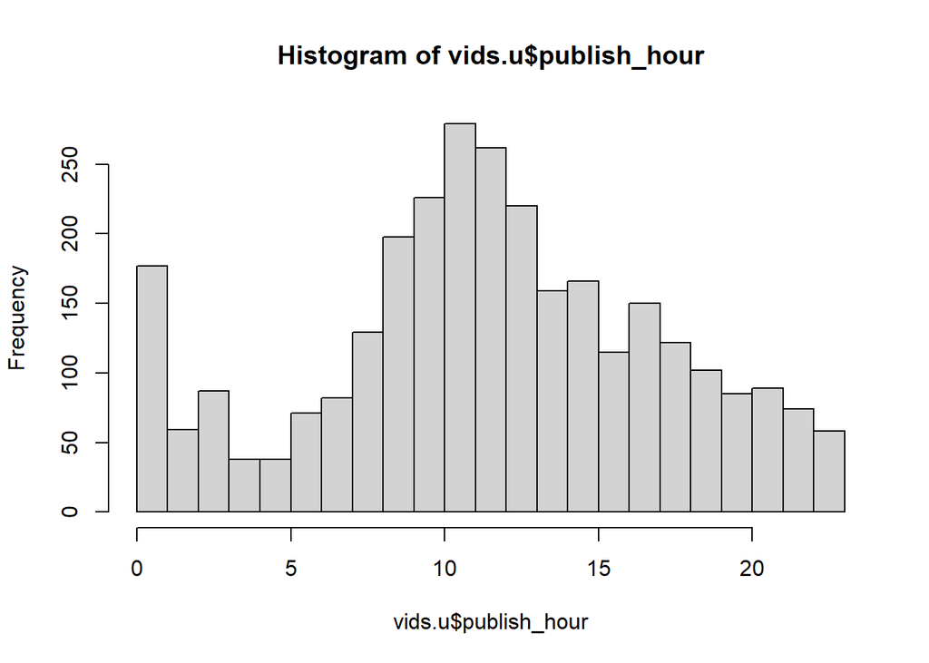

```r
# histogram
hist(vids.u$publish_hour,
     breaks = 20) # untuk membuat bar lebih detail, dinaikan dari defaultnya 10
```

- x = data range
- y = frequency

**Insight**: many videos uploaded around 10 AM

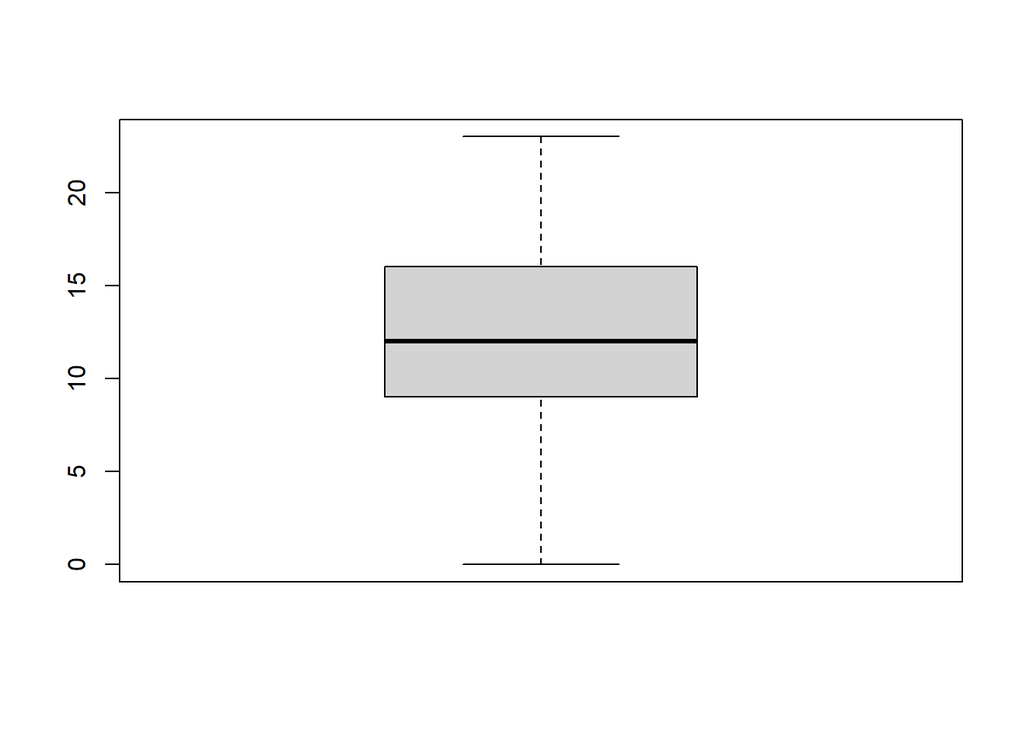

```r
# boxplot
boxplot(vids.u$publish_hour)
```

**Insight**:

- many videos uploaded at 10 AM
- there is no outlier in the data

let’s find out what day are the trending videos uploaded the most

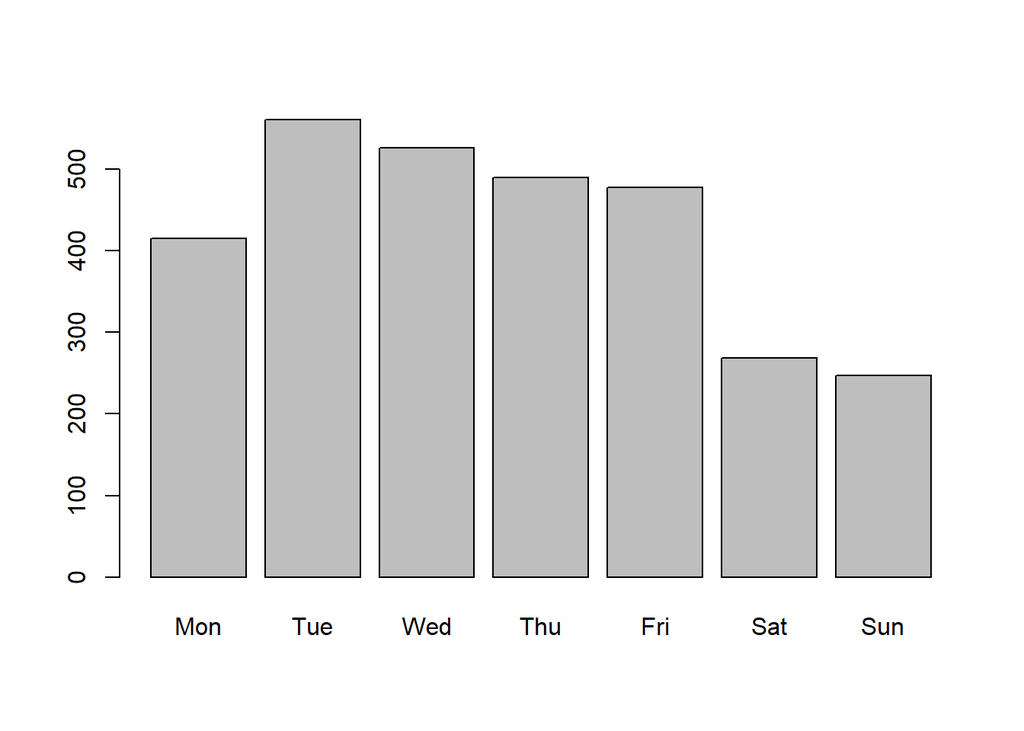

```r
plot(vids.u$publish_wday)
```

**Insight**: More videos uploaded in Tuesday-Friday than Saturday-Monday

Let’s see some correlation between columns e.g. correlation between likes per view and comment per view

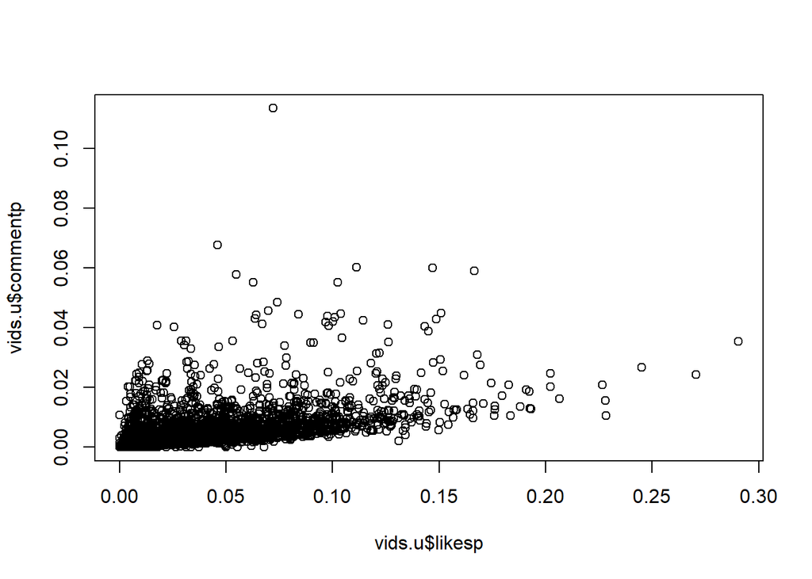

```r
plot(vids.u$likesp, vids.u$commentp)
```

```r
cor(vids.u$likesp, vids.u$commentp)
```

```
#> [1] 0.4688637
```

**Insight**: There is weak-positive correlation between likesp and commentp. When the likesp has the high value commentp has the tendency of having high value also.

## Baseplot Costumization

The base plot can be customized but it has its own difficulties.

e.g.:

**Business Question:** I’m interested in the “Autos and Vehicles”, “Gaming”, and “Travel and Events” themes. Of the three categories, is there a correlation between `likes/view` and `dislikes/view`? Are there certain characteristics for each category?

**Data Preparation**:

```r
vids.agt <- vids.u[vids.u$category_id %in% c("Autos and Vehicles",
                                             "Gaming", "Travel and Events"),]

head(vids.agt)
```

|  | trending_date | title | channel_title | category_id | publish_time | views | likes | dislikes | comment_count | publish_hour | publish_when | publish_wday | likesp | dislikesp | commentp |
| --- | --- | --- | --- | --- | --- | --- | --- | --- | --- | --- | --- | --- | --- | --- | --- |
| 31 | 2017-11-14 | I TOOK THE $3,000,000 LAMBO TO CARMAX! They offered me...... | hp_overload | Autos and Vehicles | 2017-11-12 20:43:12 | 98378 | 4035 | 495 | 486 | 20 | 4pm to 12am | Sun | 0.041015268 | 0.0050316128 | 0.0049401289 |
| 35 | 2017-11-14 | New Emirates First Class Suite \| Boeing 777 \| Emirates | Emirates | Travel and Events | 2017-11-12 00:55:42 | 141148 | 1661 | 70 | 236 | 0 | 12am to 8am | Sun | 0.011767790 | 0.0004959333 | 0.0016720039 |
| 59 | 2017-11-14 | Train Swipes Parked Vehicle | ViralHog | Autos and Vehicles | 2017-11-12 19:46:11 | 7265 | 89 | 8 | 22 | 19 | 4pm to 12am | Sun | 0.012250516 | 0.0011011700 | 0.0030282175 |
| 132 | 2017-11-14 | L.A. Noire - Nintendo Switch Trailer | Nintendo | Gaming | 2017-11-09 14:59:48 | 154872 | 7683 | 164 | 1734 | 14 | 8am to 4pm | Thu | 0.049608709 | 0.0010589390 | 0.0111963428 |
| 164 | 2017-11-14 | Caterham Chris Hoy 60 Second Donut Challenge | Caterham Cars | Autos and Vehicles | 2017-11-09 04:59:31 | 4850 | 22 | 1 | 1 | 4 | 12am to 8am | Thu | 0.004536082 | 0.0002061856 | 0.0002061856 |
| 198 | 2017-11-14 | Inside Keanu Reeves' Custom Motorcycle Shop \| WIRED | WIRED | Autos and Vehicles | 2017-11-08 10:00:27 | 704363 | 16352 | 224 | 841 | 10 | 8am to 4pm | Wed | 0.023215302 | 0.0003180178 | 0.0011939866 |

**note:** When we fetch rows with a certain category, we haven’t eliminated any other categories. We can **remove categories (levels) that do not exist in the data** with the `droplevels()` function.

```r
# check levels
levels(vids.agt$category_id)
```

```
#>  [1] "Autos and Vehicles"     "Comedy"                 "Education"
#>  [4] "Entertainment"          "Film and Animation"     "Gaming"
#>  [7] "Howto and Style"        "Music"                  "News and Politics"
#> [10] "Nonprofit and Activism" "People and Blogs"       "Pets and Animals"
#> [13] "Science and Technology" "Shows"                  "Sports"
#> [16] "Travel and Events"
```

```r
vids.agt$category_id <- droplevels(vids.agt$category_id)
```

**Buat visualisasi**:

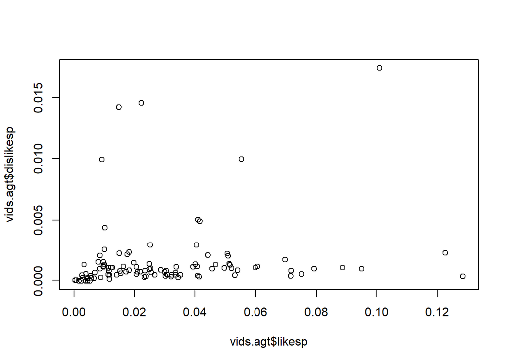

```r
plot(x = vids.agt$likesp, y = vids.agt$dislikesp)
```

We can enhance the visualization above so that the plot is more informative and interesting. The important point of good visualization is **informative plot**!

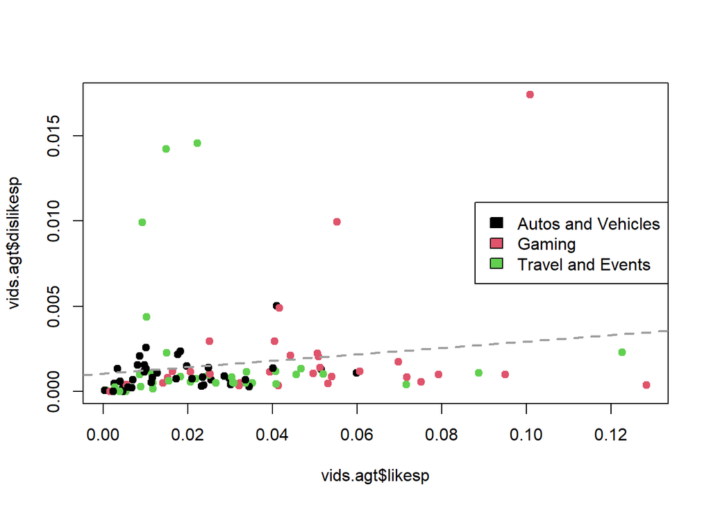

```r
plot(vids.agt$likesp, vids.agt$dislikesp,
     col = vids.agt$category_id, # warna
     pch = 19) # tipe point
abline(lm(vids.agt$dislikesp ~ vids.agt$likesp), # regression line (linear model)
       col=8, # warna
       lwd=2, # line width
       lty=2) # line type: dashed
legend("right", # posisi
       legend=levels(vids.agt$category_id), # isi legend berdasarkan category_id
       fill=1:3) # warnanya ada 3, mengikuti category id
```

## The State of Trending Videos

We are a YouTuber who wants to be careful about creating trending video content. We want to have videos with high likeability (**likes per view**), and high engagement (**comments per view**). From the `vids.agt` data, which category is the best for creating content?

Steps:

**Data Prep**

```r
head(vids.agt)
```

|  | trending_date | title | channel_title | category_id | publish_time | views | likes | dislikes | comment_count | publish_hour | publish_when | publish_wday | likesp | dislikesp | commentp |
| --- | --- | --- | --- | --- | --- | --- | --- | --- | --- | --- | --- | --- | --- | --- | --- |
| 31 | 2017-11-14 | I TOOK THE $3,000,000 LAMBO TO CARMAX! They offered me...... | hp_overload | Autos and Vehicles | 2017-11-12 20:43:12 | 98378 | 4035 | 495 | 486 | 20 | 4pm to 12am | Sun | 0.041015268 | 0.0050316128 | 0.0049401289 |
| 35 | 2017-11-14 | New Emirates First Class Suite \| Boeing 777 \| Emirates | Emirates | Travel and Events | 2017-11-12 00:55:42 | 141148 | 1661 | 70 | 236 | 0 | 12am to 8am | Sun | 0.011767790 | 0.0004959333 | 0.0016720039 |
| 59 | 2017-11-14 | Train Swipes Parked Vehicle | ViralHog | Autos and Vehicles | 2017-11-12 19:46:11 | 7265 | 89 | 8 | 22 | 19 | 4pm to 12am | Sun | 0.012250516 | 0.0011011700 | 0.0030282175 |
| 132 | 2017-11-14 | L.A. Noire - Nintendo Switch Trailer | Nintendo | Gaming | 2017-11-09 14:59:48 | 154872 | 7683 | 164 | 1734 | 14 | 8am to 4pm | Thu | 0.049608709 | 0.0010589390 | 0.0111963428 |
| 164 | 2017-11-14 | Caterham Chris Hoy 60 Second Donut Challenge | Caterham Cars | Autos and Vehicles | 2017-11-09 04:59:31 | 4850 | 22 | 1 | 1 | 4 | 12am to 8am | Thu | 0.004536082 | 0.0002061856 | 0.0002061856 |
| 198 | 2017-11-14 | Inside Keanu Reeves' Custom Motorcycle Shop \| WIRED | WIRED | Autos and Vehicles | 2017-11-08 10:00:27 | 704363 | 16352 | 224 | 841 | 10 | 8am to 4pm | Wed | 0.023215302 | 0.0003180178 | 0.0011939866 |

**Data viz**

```r
library(ggplot2)
```

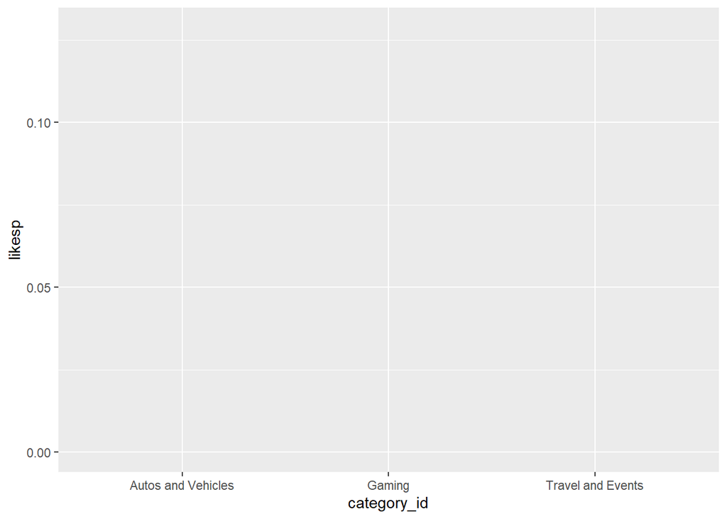

```r
# making canvas
ggplot(data = vids.agt, mapping = aes(x = category_id, y = likesp))
```

Suppose we want to compare the distribution of likes per view for each category with **boxplot**:

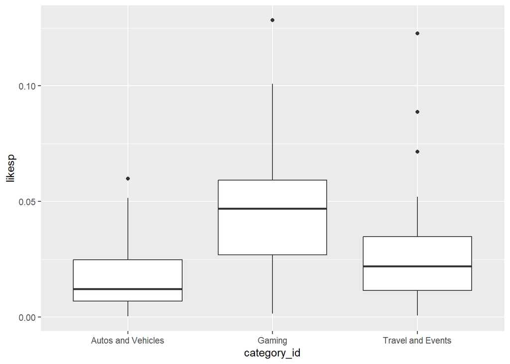

```r
ggplot(data = vids.agt, mapping = aes(x = category_id, y = likesp)) +
  geom_boxplot()
```

Misalkan kita ingin memperlihatkan distribusi data yang sebenarnya menggunakan **scatterplot**:

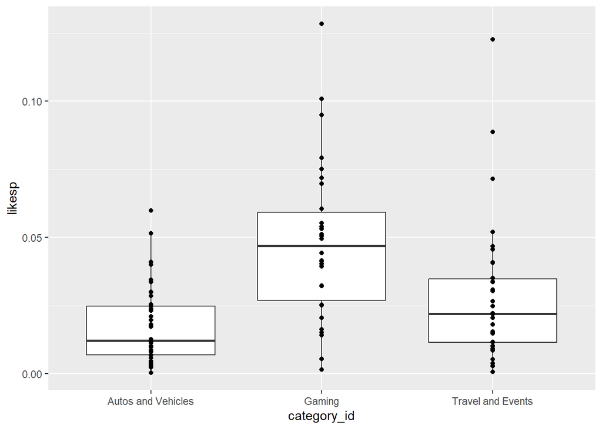

```r
ggplot(data = vids.agt, mapping = aes(x = category_id, y = likesp)) +
  geom_boxplot() +
  geom_point()
```

The data distribution is visible but still overlapping. We can solve it with **geom jitter**. Where the data points will remain according to the value, but shifted randomly to the left/right:

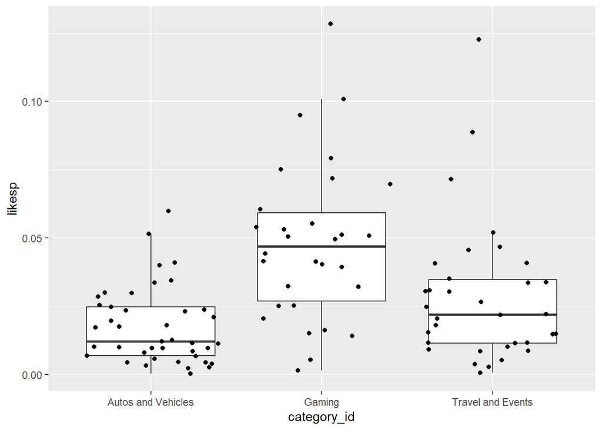

```r
ggplot(data = vids.agt, mapping = aes(x = category_id, y = likesp)) +
  geom_boxplot(outlier.shape = NA) +
  geom_jitter()
```

We can add the commentp information as a geom_jitter size:

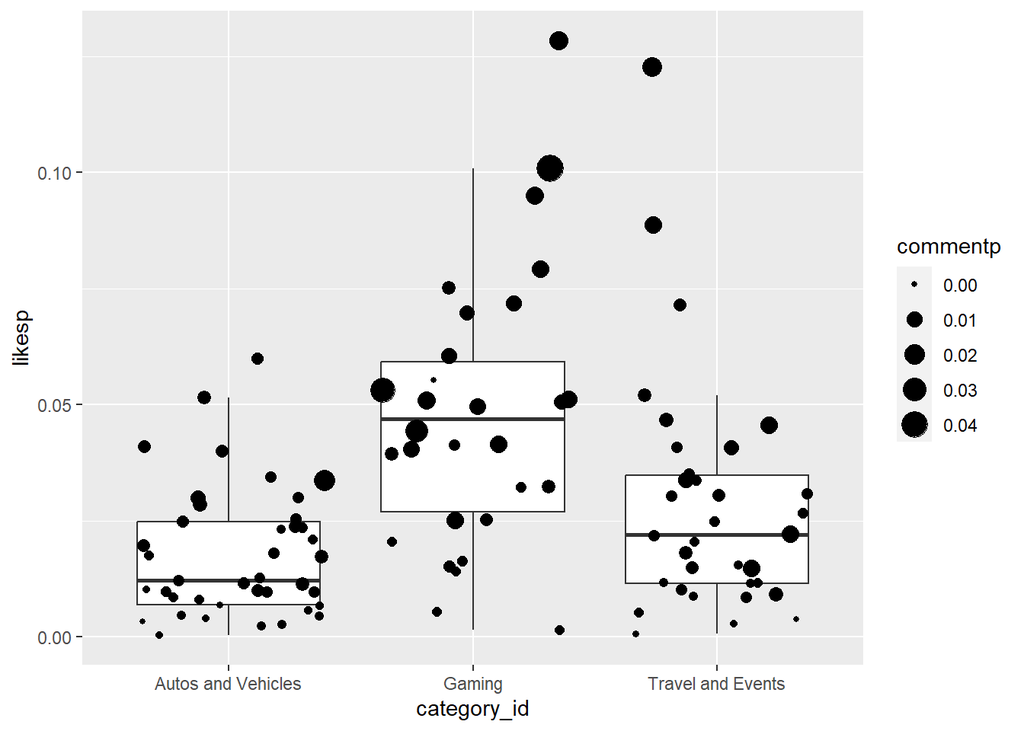

```r
ggplot(data = vids.agt, mapping = aes(x = category_id, y = likesp)) +
  geom_boxplot(outlier.shape = NA) +
  geom_jitter(aes(size = commentp))
```

**Insight:** of the three categories, the ‘gamers’ category has the video with the highest likes per view and comments per view which is also high, compared to the other two categories.

Last step, we can give some colors to make it more interesting.

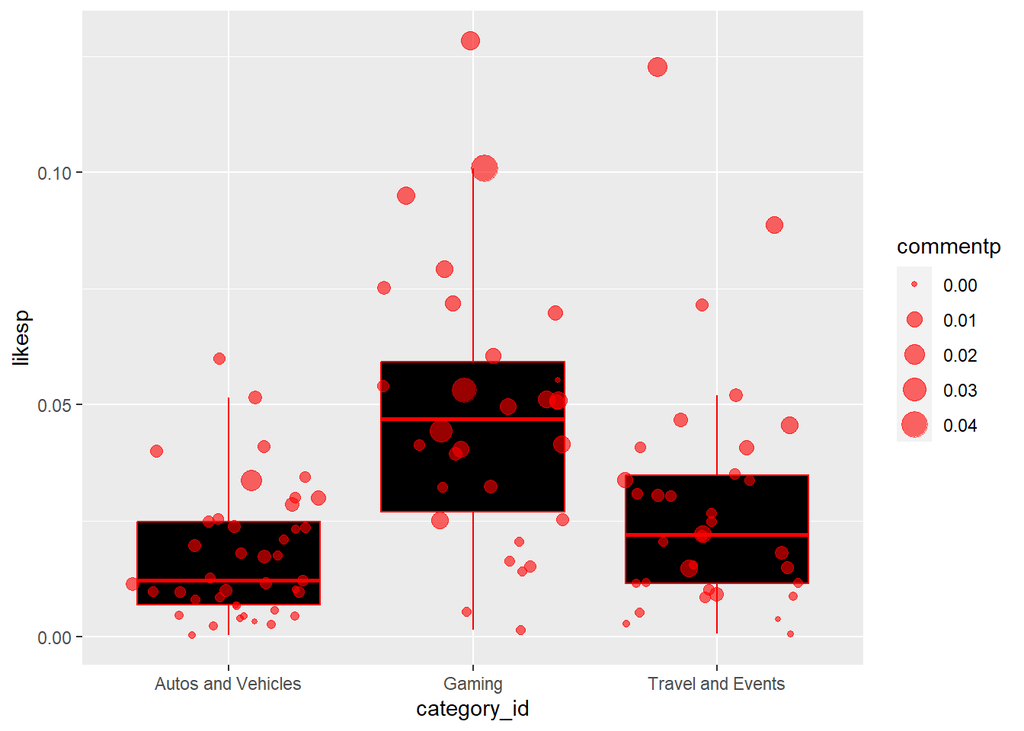

```r
# update plot terakhir
ggplot(data = vids.agt, mapping = aes(x = category_id, y = likesp)) +
  geom_boxplot(outlier.shape = NA, fill = "black", col = "red") +
  geom_jitter(aes(size = commentp), col = "red",
              alpha = 0.6) # pengaturan opacity
```

## Top Channel in Trending Videos

We are planning to collaborate with YouTube channels that appear frequently in trending video searches! Visualize the channels that have **trending videos >= 10** and sort them from highest. Which YouTube channel is good for collaborating with?

**Data Prep:**

```r
# buat data frame
vids.chan <- as.data.frame(table(vids.u$channel_title))
vids.chan <- vids.chan[vids.chan$Freq >= 10,] # filter >= 10 video trending
vids.chan <- vids.chan[order(vids.chan$Freq, decreasing = T),] # ordering berdasarkan Freq

names(vids.chan) <- c("channel_name", "total_vid")

head(vids.chan)
```

|  | channel_name | total_vid |
| --- | --- | --- |
| 1012 | Refinery29 | 31 |
| 1218 | The Tonight Show Starring Jimmy Fallon | 30 |
| 1346 | Vox | 29 |
| 1233 | TheEllenShow | 28 |
| 876 | Netflix | 27 |
| 884 | NFL | 25 |

**Data viz**

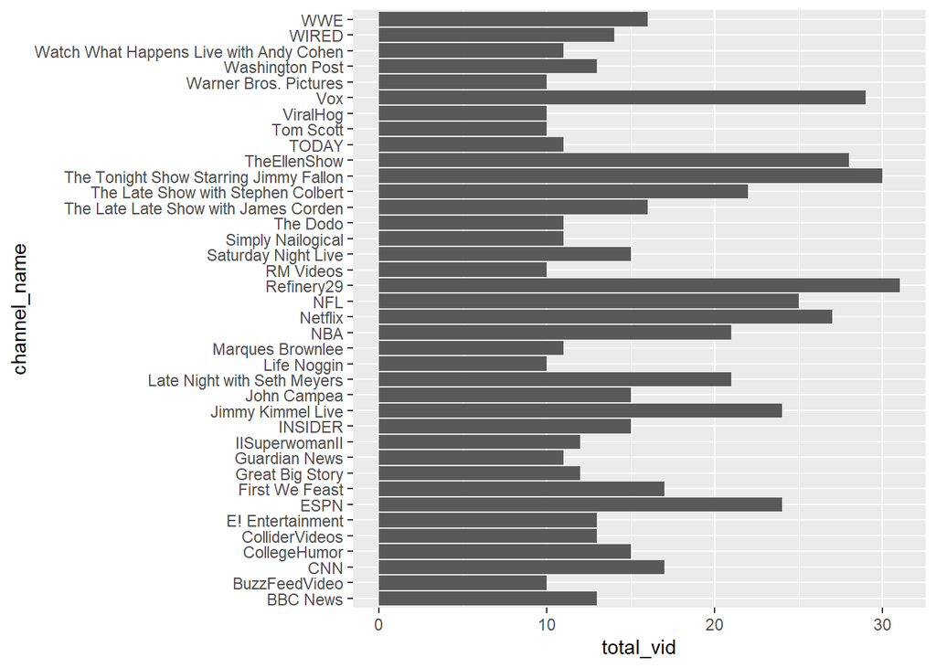

```r
# base plot
ggplot(vids.chan, aes(x = total_vid, y = channel_name)) +
  geom_col()
```

Let’s arrange the y-axis using total video and select only 10 channels.

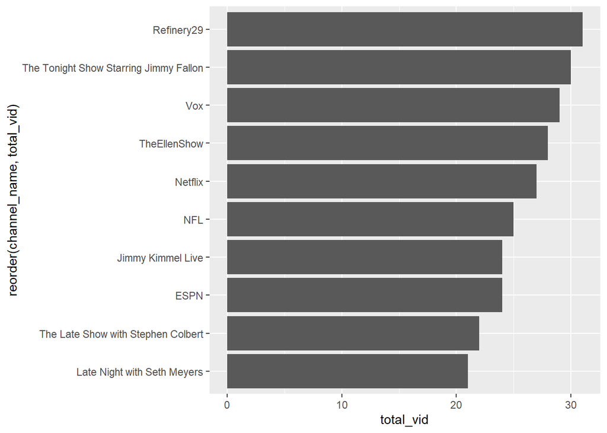

```r
ggplot(vids.chan[1:10,], aes(x = total_vid, y = reorder(channel_name, total_vid))) +
  geom_col()
```

- Set title and axis title

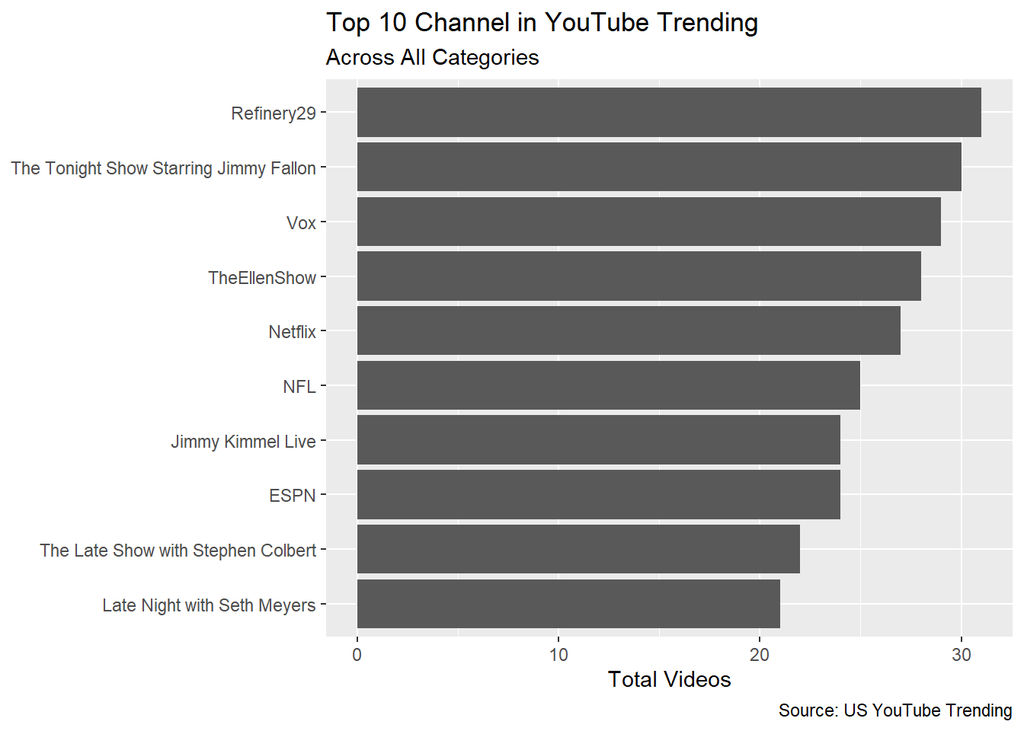

```r
ggplot(vids.chan[1:10,], aes(x = total_vid, y = reorder(channel_name, total_vid))) +
  geom_col() +
  labs(title = "Top 10 Channel in YouTube Trending",
       subtitle = "Across All Categories",
       caption = "Source: US YouTube Trending",
       x = "Total Videos",
       y = NULL)
```

- Let’s add value label for every channel

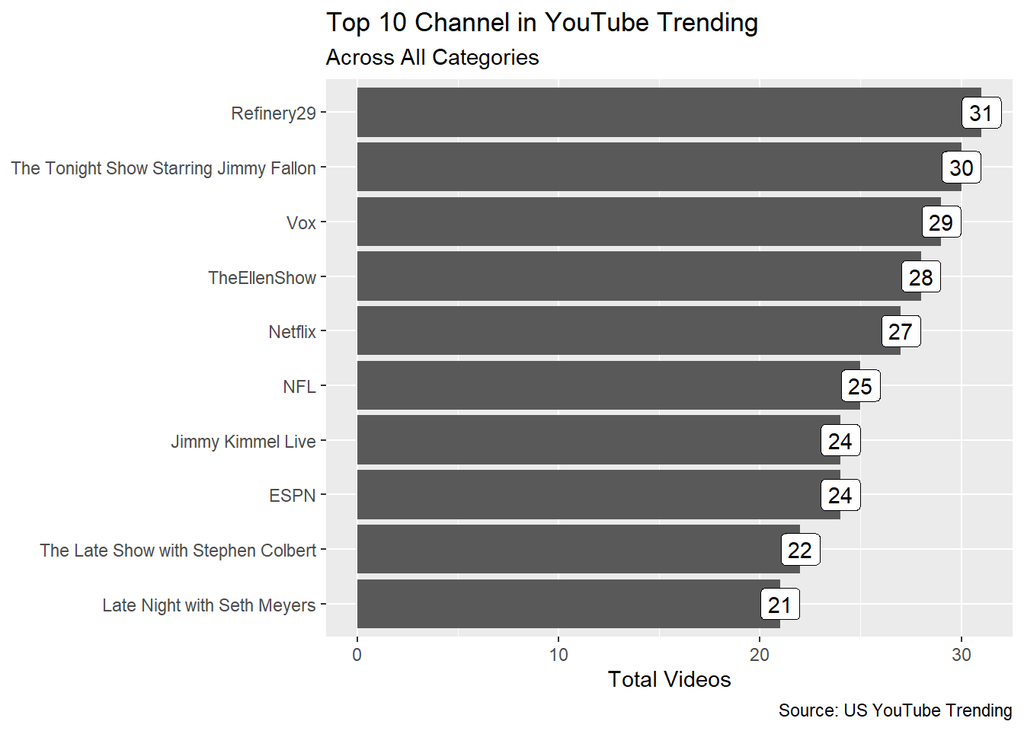

```r
ggplot(vids.chan[1:10,], aes(x = total_vid, y = reorder(channel_name, total_vid))) +
  geom_col() +
  geom_label(mapping = aes(label = total_vid)) +
  labs(title = "Top 10 Channel in YouTube Trending",
       subtitle = "Across All Categories",
       caption = "Source: US YouTube Trending",
       x = "Total Videos",
       y = NULL)
```

- add *lines to the plot*, for example: the average total_vid line of all data

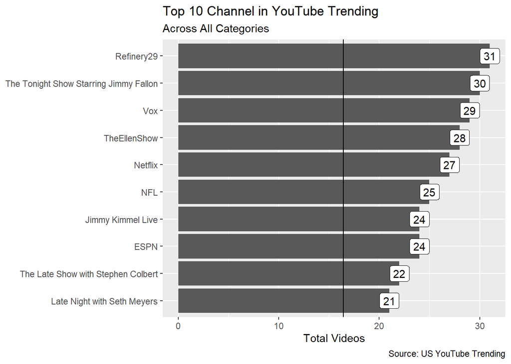

```r
ggplot(vids.chan[1:10,], aes(x = total_vid, y = reorder(channel_name, total_vid))) +
  geom_col() +
  geom_label(mapping = aes(label = total_vid)) +
  labs(title = "Top 10 Channel in YouTube Trending",
       subtitle = "Across All Categories",
       caption = "Source: US YouTube Trending",
       x = "Total Videos",
       y = NULL) +
  geom_vline(aes(xintercept = mean(total_vid)), # titik x di rata2 total vid
             data = vids.chan) # data yg digunakan berbeda dengan data awal
```

- rescale axis x (continuous)

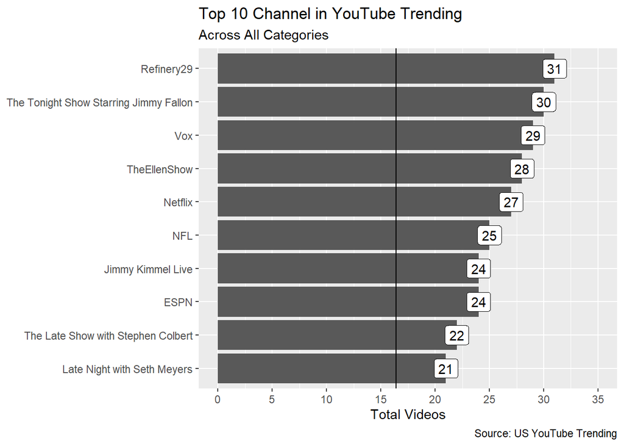

```r
ggplot(vids.chan[1:10,], aes(x = total_vid, y = reorder(channel_name, total_vid))) +
  geom_col() +
  geom_label(mapping = aes(label = total_vid)) +
  geom_vline(aes(xintercept = mean(total_vid)),
             data = vids.chan) +
  labs(title = "Top 10 Channel in YouTube Trending",
       subtitle = "Across All Categories",
       caption = "Source: US YouTube Trending",
       x = "Total Videos",
       y = NULL) +
  scale_x_continuous(breaks = seq(0,35,5), # mengatur titik tickmarks nya
                     limits = c(0,35)) # mengatur limit min-max
```

- pengaturan warna

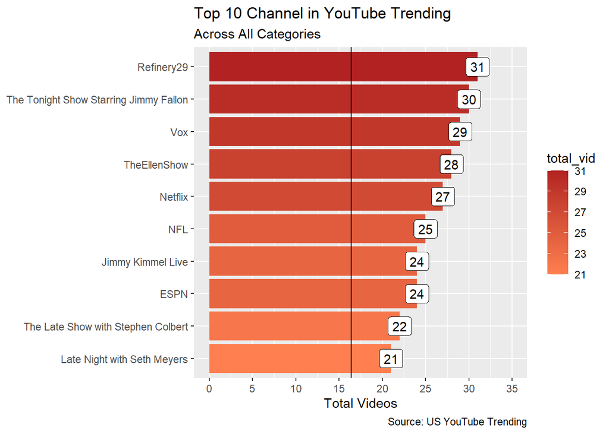

```r
ggplot(vids.chan[1:10,], aes(x = total_vid, y = reorder(channel_name, total_vid))) +
  geom_col(aes(fill = total_vid)) + # atur fill berdasarkan total_vid
  geom_label(mapping = aes(label = total_vid)) +
  geom_vline(aes(xintercept = mean(total_vid)),
             data = vids.chan) +
  labs(title = "Top 10 Channel in YouTube Trending",
       subtitle = "Across All Categories",
       caption = "Source: US YouTube Trending",
       x = "Total Videos",
       y = NULL) +
  scale_x_continuous(breaks = seq(0,35,5),
                     limits = c(0,35)) +
  scale_fill_gradient(low = "coral", high = "firebrick") # atur skala fill manual
```

[figure not shown]

```r
ggplot(vids.chan[1:10,], aes(x = total_vid, y = reorder(channel_name, total_vid))) +
  geom_col(aes(fill = total_vid), col = "#d63e2d", show.legend = F) +
  geom_label(mapping = aes(label = total_vid),
             data = vids.chan[1:5,]) +
  labs(title = "Top 15 Channel in YouTube Trending",
       subtitle = "Across All Categories",
       caption = "Source: US YouTube Trending",
       x = "Total Videos",
       y = NULL) +
  scale_x_continuous(breaks = seq(0,35,5),
                     limits = c(0,35)) +
  scale_fill_gradient(low = "ivory", high = "#d63e2d") +
  scale_y_discrete(labels = scales::wrap_format(25)) +
  geom_vline(aes(xintercept = mean(total_vid)),
             data = vids.chan)
```

**Business Question:** We want to visualize the number of videos (`title`) published for each category (`category_id`) and at a certain time (`publish_when`).

**Steps:**

1. **Data prep**

```r
# aggregasi data
vids.agg <- aggregate(title ~ category_id + publish_when,
                      data = vids,
                      FUN = length) # jml baris

# perbaiki nama kolom
names(vids.agg) <- c("category_id","publish_when","vid_count")

head(vids.agg)
```

|  | category_id | publish_when | vid_count |
| --- | --- | --- | --- |
| 1 | Autos and Vehicles | 12am to 8am | 22 |
| 2 | Comedy | 12am to 8am | 197 |
| 3 | Education | 12am to 8am | 19 |
| 4 | Entertainment | 12am to 8am | 541 |
| 5 | Film and Animation | 12am to 8am | 61 |
| 6 | Gaming | 12am to 8am | 10 |

2. **Data viz**

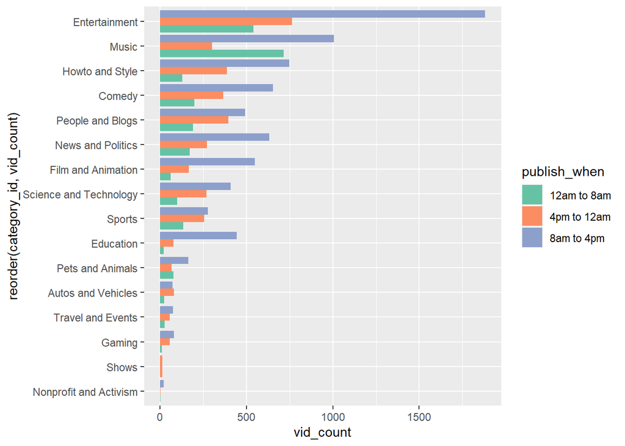

```r
ggplot(vids.agg, aes(x = vid_count, y = reorder(category_id, vid_count))) +
  geom_col(aes(fill = publish_when), position = "dodge") +
  scale_fill_brewer(palette = "Set2")
```

**Insight**:

- videos that are published a lot at 8am-4pm and 4pm-12am are entertainment
- the videos that are published a lot at 12am-8am are music

**Business Question:** We want to visualize the proportion of videos published at a certain time (`publish_when`) for each category (`category_id`).

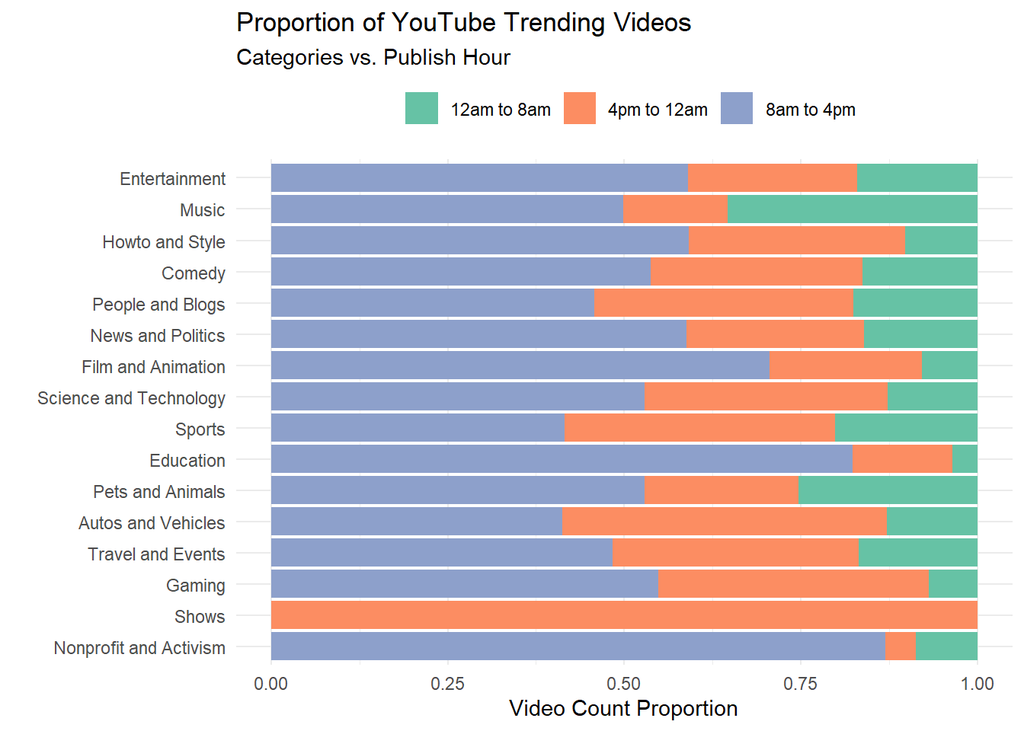

```r
# position fill
ggplot(vids.agg, aes(x = vid_count, y = reorder(category_id, vid_count))) +
  geom_col(mapping = aes(fill = publish_when), position = "fill") +
  labs(x = "Video Count Proportion",
       y = "",
       fill = "",
       title = "Proportion of YouTube Trending Videos",
       subtitle = "Categories vs. Publish Hour") +
  scale_fill_brewer(palette = "Set2") +
  theme_minimal() +
  theme(legend.position = "top")
```

**Insight**:

- In general, many videos are published at 8am-4pm
- The Shows category only has videos published between 4pm-12am

**Business Question:** What category has the most trending videos? At what time are most of the trending videos from this category published?

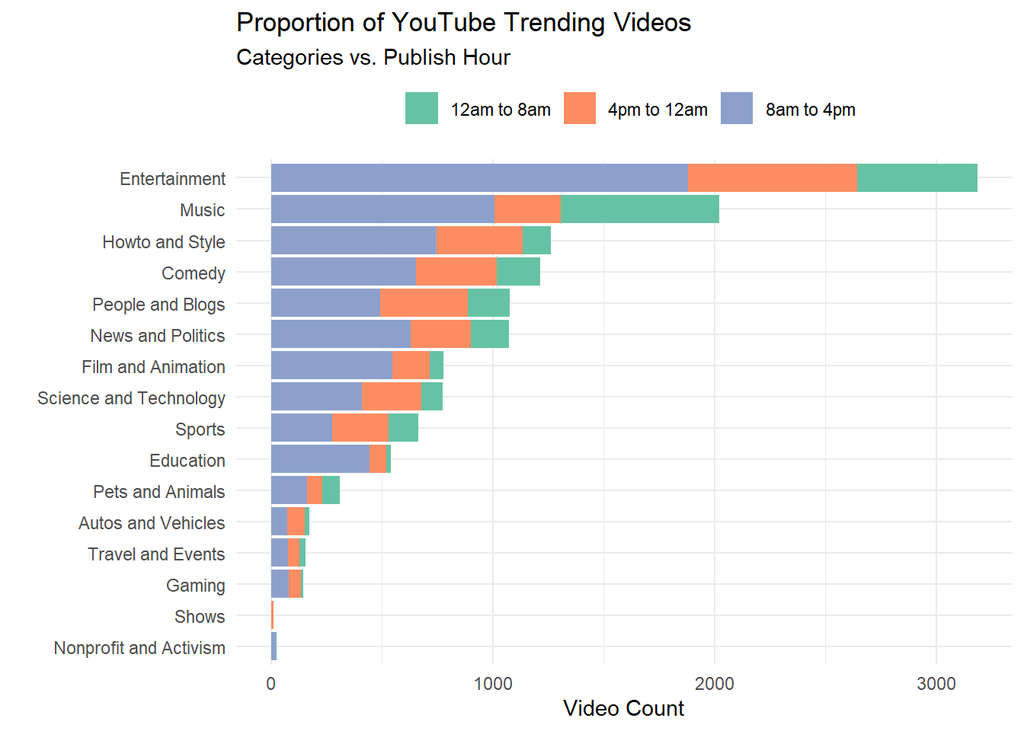

```r
# position stack
ggplot(vids.agg, aes(x = vid_count, y = reorder(category_id, vid_count))) +
  geom_col(mapping = aes(fill = publish_when), position = "stack") +
  labs(x = "Video Count",
       y = "",
       fill = "",
       title = "Proportion of YouTube Trending Videos",
       subtitle = "Categories vs. Publish Hour") +
  scale_fill_brewer(palette = "Set2") +
  theme_minimal() +
  theme(legend.position = "top")
```

**Insight**: The category whose videos are included in the most trending video rows is Entertainment, with video publishing hours from 8 am to 4 pm.